# anantha_dl (2)

## COMP5625M Assessment 1 - Image Classification [100 marks]

[figure not shown]

The maximum number of marks for each part are shown in the section headers. As indicated in the main heading above, the overall assessment carries a maximum of 100 marks.

This summative assessment is weighted 25% of the final grade for the module.

### Motivation

Through this assessment, you will gain practical experience in:

> 1. Implementing and evaluating a multi-layer perceptron (MLP) and convolutional neural network (CNN) in solving a classification problem
> 2. Building, evaluating, and finetuning a CNN on an image dataset from development to testing
> 3. Tackling overfitting using strategies such as data augmentation and drop out
> 4. Fine tuning a model
> 5. Comparing the performance of a new model with an off-the-shelf model (AlexNet)
> 6. Gaining a deeper understanding of model performance using visualisations from Grad-CAM.

### Setup and resources

You must work using this template notebook.

Having a GPU will speed up the training process. See the provided document on Minerva about setting up a working environment for various ways to access a GPU. We highly recommend you use platforms such as Colab.

Please implement the coursework using **Python and PyTorch**, and refer to the notebooks and exercises provided.

This coursework will use a subset of images from Tiny ImageNet, which is a subset of the [ImageNet dataset](https://www.image-net.org/update-mar-11-2021.php). Our subset of Tiny ImageNet contains **30 different categories**, we will refer to it as TinyImageNet30. The training set has 450 resized images (64x64 pixels) for each category (13,500 images in total). You can download the training and test set from a direct link or the Kaggle challenge website:

> [Direct access to data is possible by clicking here, please use your university email to access this](https://leeds365-my.sharepoint.com/:u:/g/personal/scssali_leeds_ac_uk/ESF87mN6kelIkjdISkaRow8BublW27jB-P8eWV6Rr4rxtw?e=SPASDB)

> [Access data through Kaggle webpage](https://www.kaggle.com/t/917fe52f6a3c4855880a24b34f26db07)

### Required submissions

##### 1. Kaggle Competition

To participate in the submission of test results, you will need an account. Even if you have an existing Kaggle account, please carefully adhere to these instructions, or we may not be able to locate your entries:

> 1. Use your **university email** to register a new account.
> 2. Set your **Kaggle account NAME** to your university username, for example, `sc15jb`.

The class Kaggle competition also includes a blind test set, which will be used in Question 1 for evaluating your custom model's performance on a test set. The competition website will compute the test set accuracy, as well as position your model on the class leaderboard. [Link to submit your results on Kaggle competition](https://www.kaggle.com/competitions/comp5623m-artificial-intelligence/submissions).

Please submit only your predictions from test set - detailed instructions are provided in (3)

##### 2. Submission of your work

Please submit the following:

> 1. Your completed Jupyter notebook file, without removing anything in the template, in **.ipynb format.**
> 2. The **.html version** of your notebook; File > Download as > HTML (.html). Check that all cells have been run and all outputs (including all graphs you would like to be marked) displayed in the .html for marking.
> 3. Your selected images from section 6 "Failure/success analysis" (outputs from gradcam, for example you can put these images into failure and succcess folders).

**Final note:**

> **Please display everything that you would like to be marked. Under each section, put the relevant code containing your solution. You may re-use functions you defined previously, but any new code must be in the relevant section.** Feel free to add as many code cells as you need under each section.

Your student username (for example, `sc15jb`):

--> sc22angs

Your full name:

## Required packages

[1] [numpy](http://www.numpy.org) is a package for scientific computing with python

[2] [h5py](http://www.h5py.org) is a package to interact with compactly stored dataset

[3] [matplotlib](http://matplotlib.org) can be used for plotting graphs in python

[4] [pytorch](https://pytorch.org/docs/stable/index.html) is a library widely used for bulding deep-learning frameworks

Feel free to add to this section as needed - examples of importing libraries are provided below.

You may need to install these packages using [pip](https://pypi.org/project/opencv-python/) or [conda](https://anaconda.org/conda-forge/opencv).

```python
import math

import numpy as np
import torch
from torch import nn, optim
import torchvision.transforms as transforms
from torch.hub import load_state_dict_from_url

from PIL import Image
import matplotlib.pyplot as plt
```

```python
# always check your version
print(torch.__version__)
device = torch.device('cuda' if torch.cuda.is_available() else 'cpu')
print('Using device:', device)
```

```
1.13.1
Using device: cuda
```

One challenge of building a deep learning model is to choose an architecture that can learn the features in the dataset without being unnecessarily complex. The first part of the coursework involves building a CNN and training it on TinyImageNet30.

### **Overview:**

**1. Function implementation** (12 marks)

- **1.1** PyTorch `Dataset` and `DataLoader` classes (4 marks)
- **1.2** PyTorch `Model` class for a simple MLP model (4 marks)
- **1.3** PyTorch `Model` class for a simple CNN model (4 marks)

**2. Model training** (20 marks)

- **2.1** Train on TinyImageNet30 dataset (7 marks)
- **2.2** Generate confusion matrices and ROC curves (4 marks)
- **2.3** Strategies for tackling overfitting (9 marks)
  - **2.3.1** Data augmentation
  - **2.3.2** Dropout
  - **2.3.3** Hyperparameter tuning (e.g. changing learning rate)

**3. Model Fine-tuning on CIFAR10 dataset** (20 marks)

- **3.1** Fine-tune your model (initialise your model with pretrained weights from (2)) (8 marks)
- **3.2** Fine-tune model with frozen base convolution layers (8 marks)
- **3.3** Compare complete model retraining with pretrained weights and with frozen layers. Comment on what you observe? (4 marks)

**4. Model testing** (18 marks)

- **4.1** Test your final model in (2) on test set - code to do this (10 marks)
- **4.2** Upload your result to Kaggle (8 marks)

**5. Model comparison** (14 marks)

- **5.1** Load pretrained AlexNet and finetune on TinyImageNet30 until model convergence (6 marks)
- **5.2** Compare the results of your CNN model with pretrained AlexNet on the same validation set. Provide performance values (loss graph, confusion matrix, top-1 accuracy, execution time) (8 marks)

**6. Interpretation of results** (16 marks)

- **6.1** Use grad-CAM on your model and on AlexNet (6 marks)
- **6.2** Visualise and compare the results from your model and from AlexNet (4 marks)
- **6.3** Comment on (6 marks):
  - why the network predictions were correct or not correct in your predictions?
  - what can you do to improve your results further?

## 1 Function implementations [12 marks]

### 1.1 Dataset class [4 marks]

Write a PyTorch `Dataset` class (an example [here](https://www.askpython.com/python-modules/pytorch-custom-datasets) for reference) which loads the TinyImage30 dataset and `DataLoaders` for training and validation sets.

```python
# TO COMPLETE
# Imports
import os
from PIL import Image
from torch.utils.data import Dataset,DataLoader
from natsort import natsorted
from torchvision import datasets, transforms

# Define your own class LoadFromFolder
class LoadFromFolder(Dataset):
    def __init__(self, main_dir, transform):

        # Set the loading directory
        self.main_dir = main_dir
        self.transform = transform

        # List all images in folder and count them
        all_imgs = os.listdir(main_dir)
        self.total_imgs = natsorted(all_imgs)
    def __len__(self):
    # Return the previously computed number of images
      return len(self.total_imgs)

    def __getitem__(self, idx):
      img_loc = os.path.join(self.main_dir, self.total_imgs[idx])

      # Use PIL for image loading
      image = Image.open(img_loc).convert("RGB")
      # Apply the transformations
      tensor_image = self.transform(image)
      return tensor_image
```

```python
from torchvision.datasets import ImageFolder
from sklearn.model_selection import train_test_split
import torchvision
DataPath =  "C:/Users/shahn/Downloads/train_set/train_set/train_set"
ResultPath = "C:/Users/shahn/Downloads/test_set/test_set/test_set"

resize = transforms.Compose([
    transforms.Resize((64,64)),
    transforms.ToTensor(),
    transforms.Normalize((0.485, 0.456, 0.406), (0.229, 0.224, 0.225))
])

train_set = ImageFolder(root=DataPath, transform=resize)
train_div, val_div = train_test_split(range(len(train_set)), test_size=0.2, random_state=0)
train_data = torch.utils.data.Subset(train_set, train_div)
val_data = torch.utils.data.Subset(train_set, val_div)

train_loader = DataLoader(train_data,batch_size=32,shuffle=True)
val_dataloader = DataLoader(val_data, batch_size =32, shuffle=True)
#all_labels = []
#for images, labels in train_loader:
#    all_labels.append(labels)


#print(train_images)
train_iter = iter(train_loader)
# images, labels = dataiter.next()
train_images, labels = next(train_iter)
```

```python
print(labels)
```

```
tensor([20,  5, 13, 10, 14,  0, 21, 10, 16, 21, 15,  6,  4, 29, 22, 19, 15, 14,
        18, 29,  4, 22,  7, 17,  2, 12,  1,  7,  6,  5, 12, 16])
```

```
Clipping input data to the valid range for imshow with RGB data ([0..1] for floats or [0..255] for integers).
```

```
torch.Size([32, 3, 64, 64])
```

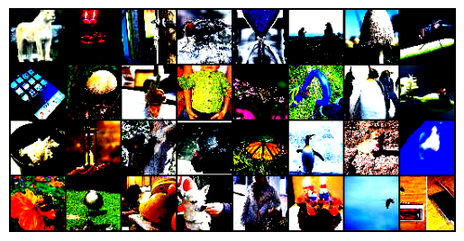

```
20 5 13 10 14 0 21 10 16 21 15 6 4 29 22 19 15 14 18 29 4 22 7 17 2 12 1 7 6 5 12 16
```

```python
def timshow(x):
    xa = np.transpose(x.numpy(),(1,2,0))
    plt.imshow(xa)
    plt.axis('off')
    plt.show()
    return xa


print(train_images.size())
timshow(torchvision.utils.make_grid(train_images))
print(*labels.numpy())     # asterisk unpacks the ndarray
```

### 1.2 Define a MLP model class [4 marks]

Create a new model class using a combination of:

- Input Units
- Hidden Units
- Output Units
- Activation functions
- Loss function
- Optimiser

```python
# TO COMPLETE
# define a MLP Model class



class MLP(nn.Module):
    def __init__(self):
        super(MLP, self).__init__()
        self.flat = nn.Flatten()
        self.linear1 = nn.Linear(3*64*64, 256)
        self.linear2 = nn.Linear(256, 64)
        self.linear3 = nn.Linear(64, 30)
        self.relu = nn.ReLU()
        #self.dropout = nn.Dropout(p=0.5)
        self.log_softmax = nn.LogSoftmax(dim=1)
        self.loss_fn = nn.CrossEntropyLoss()
        self.optimizer = optim.Adam(self.parameters(), lr=0.001)

    def forward(self, x):
        x = x.view(-1, 3 * 64 * 64)
        x = self.relu(self.linear1(x))
        x = self.relu(self.linear2(x))
        #x = self.dropout(x)
        x = self.linear3(x)
        x = self.log_softmax(x)
        return x
```

### 1.3 Define a CNN model class [4 marks]

Create a new model class using a combination of:

- Convolution layers
- Activation functions (e.g. ReLU)
- Maxpooling layers
- Fully connected layers
- Loss function
- Optimiser

```python
import torch.nn as nn
import torch.optim as optim

class CNN(nn.Module):
    def __init__(self, l_rate=0.01):
        super(CNN, self).__init__()

        self.flat= nn.Flatten()
        # Define convolutional layers
        self.conv1 = nn.Conv2d(3, 32, kernel_size=3)
        self.conv2 = nn.Conv2d(32, 64, kernel_size=3)
        self.conv3 = nn.Conv2d(64, 128, kernel_size=3)

        # Define fully-connected layers
        self.fc1 = nn.Linear(128 * 28 * 28, 128)
        self.fc2 = nn.Linear(128, 30)

        self.pool = nn.MaxPool2d(kernel_size=2)

        # Define activation functions
        self.relu = nn.ReLU()
        #self.log_softmax = nn.LogSoftmax(dim=1)

        # Define loss function and optimizer
        self.loss_fn = nn.CrossEntropyLoss()
        self.optimizer = optim.SGD(self.parameters(), lr=l_rate)


    def forward(self, x):

        # Perform convolutional operations and activation functions
        x = self.relu(self.conv1(x))
        x = self.relu(self.conv2(x))
        x = self.pool(x)
        x = self.relu(self.conv3(x))

        # Flatten the output
        x = x.view(x.size(0),-1)

        # Perform fully-connected operations and activation functions
        x = self.relu(self.fc1(x))
        x = self.fc2(x)
        #x = self.log_softmax(x)

        return x
```

## 2 Model training [20 marks]

### 2.1 Train both MLP and CNN models - show loss and accuracy graphs side by side [7 marks]

Train your model on the TinyImageNet30 dataset. Split the data into train and validation sets to determine when to stop training. Use seed at 0 for reproducibility and test_ratio=0.2 (validation data)

Display the graph of training and validation loss over epochs and accuracy over epochs to show how you determined the optimal number of training epochs. Top-*k* accuracy implementation is provided for you below.

> Please leave the graph clearly displayed. Please use the same graph to plot graphs for both train and validation.

```python
#TO COMPLETE --> Running you MLP model class
nepochs = 30
mlp = MLP()
train_losses = []
train_accs = []
val_losses = []
val_accs = []
mlp.to('cuda:0')
for epoch in range(nepochs):
    # Train the model for one epoch
    mlp.train()
    running_loss = 0.0
    correct = 0
    total = 0
    running_val_loss = 0.0
    num_val_samples = 0
    num_val_correct = 0
    for inputs, labels in train_loader:
        # Get the inputs and labels
        #inputs, labels = data
        inputs, labels = inputs.to('cuda:0'), labels.to('cuda:0')
        # Zero the parameter gradients
        mlp.optimizer.zero_grad()

        # Forward pass
        outputs = mlp(inputs)

        # Compute the loss
        loss = mlp.loss_fn(outputs, labels)

        # Backward pass and update weights
        loss.backward()
        mlp.optimizer.step()

        # Print statistics
        running_loss += loss.item()
        _, predicted = torch.max(outputs.data, 1)
        total += labels.size(0)
        correct += (predicted == labels).sum().item()


    # Compute and record the average training loss and accuracy for this epoch
    train_loss = running_loss / len(train_loader.dataset)
    train_acc = 100 * correct / total
    train_losses.append(train_loss)
    train_accs.append(train_acc)

    # Print epoch results
    #print(f"Epoch {epoch+1}: Train Loss={train_loss:.5f}, Train Acc={train_acc:.2f}%")
    mlp.eval()
    # Evaluate the model on the validation set
    with torch.no_grad():
        for batch_idx, (images, labels) in enumerate(val_dataloader):
            images = images.to(device)
            labels = labels.to(device)
            mlp1 = mlp.to(device)  # move model to device
            output = mlp1(images.view(-1, 3*64*64))
            loss = mlp1.loss_fn(output, labels)
            running_val_loss += loss.item() * images.size(0)
            num_val_samples += images.size(0)
            _, predicted = torch.max(output.data, 1)
            num_val_correct += (predicted == labels).sum().item()


    # Compute the validation loss and accuracy for the epoch
    val_loss = running_val_loss / num_val_samples
    val_acc = (num_val_correct / num_val_samples) * 100
    val_losses.append(val_loss)
    val_accs.append(val_acc)


    # Print the training and validation losses and accuracies for the epoch
    print(f"Epoch {epoch+1} | Train Loss: {train_loss:.4f} | Train Acc: {train_acc:.4f} | Val Loss: {val_loss:.4f} | Val Acc: {val_acc:.4f}")
    # save network parameters and losses
```

```
Epoch 1 | Train Loss: 0.1018 | Train Acc: 9.1759 | Val Loss: 3.0386 | Val Acc: 12.9259
Epoch 2 | Train Loss: 0.0933 | Train Acc: 14.2130 | Val Loss: 3.0070 | Val Acc: 14.0741
Epoch 3 | Train Loss: 0.0882 | Train Acc: 18.1111 | Val Loss: 3.0195 | Val Acc: 15.6296
Epoch 4 | Train Loss: 0.0843 | Train Acc: 21.0463 | Val Loss: 2.9197 | Val Acc: 16.5926
Epoch 5 | Train Loss: 0.0805 | Train Acc: 24.0093 | Val Loss: 2.9420 | Val Acc: 17.1481
Epoch 6 | Train Loss: 0.0766 | Train Acc: 27.8981 | Val Loss: 2.9849 | Val Acc: 16.8148
Epoch 7 | Train Loss: 0.0733 | Train Acc: 30.2778 | Val Loss: 3.0671 | Val Acc: 17.1481
Epoch 8 | Train Loss: 0.0694 | Train Acc: 33.1574 | Val Loss: 3.2267 | Val Acc: 17.5556
Epoch 9 | Train Loss: 0.0653 | Train Acc: 36.1759 | Val Loss: 3.2713 | Val Acc: 18.0370
Epoch 10 | Train Loss: 0.0613 | Train Acc: 40.2778 | Val Loss: 3.3684 | Val Acc: 18.7778
Epoch 11 | Train Loss: 0.0577 | Train Acc: 43.2500 | Val Loss: 3.4901 | Val Acc: 18.3704
Epoch 12 | Train Loss: 0.0543 | Train Acc: 46.2315 | Val Loss: 3.7525 | Val Acc: 17.1111
Epoch 13 | Train Loss: 0.0518 | Train Acc: 49.2222 | Val Loss: 3.8340 | Val Acc: 18.0741
Epoch 14 | Train Loss: 0.0477 | Train Acc: 53.1389 | Val Loss: 4.0626 | Val Acc: 18.5185
Epoch 15 | Train Loss: 0.0464 | Train Acc: 53.7315 | Val Loss: 4.1301 | Val Acc: 16.5556
Epoch 16 | Train Loss: 0.0430 | Train Acc: 57.1111 | Val Loss: 4.6598 | Val Acc: 17.5926
Epoch 17 | Train Loss: 0.0430 | Train Acc: 57.1574 | Val Loss: 4.6653 | Val Acc: 18.8889
Epoch 18 | Train Loss: 0.0406 | Train Acc: 59.2037 | Val Loss: 4.6067 | Val Acc: 18.6667
Epoch 19 | Train Loss: 0.0376 | Train Acc: 61.5556 | Val Loss: 4.9262 | Val Acc: 17.9630
Epoch 20 | Train Loss: 0.0368 | Train Acc: 62.8148 | Val Loss: 5.0423 | Val Acc: 17.9259
Epoch 21 | Train Loss: 0.0365 | Train Acc: 63.2500 | Val Loss: 5.2189 | Val Acc: 18.2222
Epoch 22 | Train Loss: 0.0332 | Train Acc: 66.0833 | Val Loss: 5.4257 | Val Acc: 18.5185
Epoch 23 | Train Loss: 0.0326 | Train Acc: 67.0648 | Val Loss: 5.6635 | Val Acc: 17.0000
Epoch 24 | Train Loss: 0.0328 | Train Acc: 66.5370 | Val Loss: 5.7847 | Val Acc: 17.5185
Epoch 25 | Train Loss: 0.0311 | Train Acc: 67.9167 | Val Loss: 5.5985 | Val Acc: 17.4074
Epoch 26 | Train Loss: 0.0312 | Train Acc: 68.1667 | Val Loss: 6.3327 | Val Acc: 17.2963
Epoch 27 | Train Loss: 0.0305 | Train Acc: 69.0370 | Val Loss: 6.5894 | Val Acc: 17.2222
Epoch 28 | Train Loss: 0.0292 | Train Acc: 70.2593 | Val Loss: 6.7099 | Val Acc: 17.9259
Epoch 29 | Train Loss: 0.0277 | Train Acc: 71.5463 | Val Loss: 6.8937 | Val Acc: 17.8148
Epoch 30 | Train Loss: 0.0287 | Train Acc: 70.9352 | Val Loss: 7.0351 | Val Acc: 17.0000
```

```python
def plotGraphs(train_losses,val_losses,train_accs,val_accs):
    # Your graph
    fig, (graph1, graph2) = plt.subplots(1, 2, figsize=(12, 5))

    # Training and validation loss
    graph1.plot(train_losses, 'r', label='training loss')
    graph1.plot(val_losses, 'b', label='validation loss')
    graph1.legend()
    graph1.set_xlabel('epoch')
    graph1.set_ylabel('loss')
    graph1.set_title('Training and Validation Loss')

    # Training and validation accuracy
    graph2.plot(train_accs, 'g', label='training accuracy')
    graph2.plot(val_accs, 'c-', label='validation accuracy')
    graph2.legend()
    graph2.set_xlabel('epoch')
    graph2.set_ylabel('accuracy')
    graph2.set_title('Training and Validation Accuracy')

    plt.show()
```

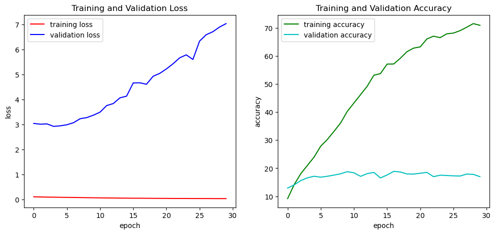

```python
# Your graph
plotGraphs(train_losses,val_losses,train_accs,val_accs)
```

```python
def new_CNN(epochs=20, learning_rate=0.01):
    nepochs = epochs
    cnn = CNN(l_rate=learning_rate)
    train_losses = []
    train_accs = []
    val_losses = []
    val_accs = []
    cnn.to('cuda:0')
    for epoch in range(nepochs):
        # Train the model for one epoch
        cnn.train()
        running_loss = 0.0
        correct = 0
        total = 0
        running_val_loss = 0.0
        num_val_samples = 0
        num_val_correct = 0
        train_preds = []
        train_labels = []
        val_preds = []
        val_labels = []
        val_probs = []
        for inputs, labels in train_loader:
            # Get the inputs and labels
            #inputs, labels = data
            inputs, labels = inputs.to('cuda:0'), labels.to('cuda:0')
            # Zero the parameter gradients
            cnn.optimizer.zero_grad()

            # Forward pass
            outputs = cnn(inputs)
            # Compute the loss
            loss = cnn.loss_fn(outputs, labels)
            # Backward pass and update weights
            loss.backward()
            cnn.optimizer.step()
            # Print statistics
            running_loss += loss.item() * inputs.size(0)
            _, predicted = torch.max(outputs.data, 1)
            total += inputs.size(0)
            correct += (predicted == labels).sum().item()
            train_preds.extend(predicted.cpu().numpy())
            train_labels.extend(labels.cpu().numpy())

        # Compute and record the average training loss and accuracy for this epoch
        train_loss = running_loss / len(train_loader.dataset)
        train_acc = 100 * correct / total
        train_losses.append(train_loss)
        train_accs.append(train_acc)

        with torch.no_grad():
            for images, labels in val_dataloader:
                images = images.to(device)
                labels = labels.to(device)
                output = cnn(images)
                loss = cnn.loss_fn(output, labels)
                running_val_loss += loss.item() * images.size(0)
                _, predicted = torch.max(output.data, 1)
                num_val_samples += images.size(0)
                num_val_correct += (predicted == labels).sum().item()
                val_preds.extend(predicted.cpu().numpy())
                val_labels.extend(labels.cpu().numpy())
                probs = torch.nn.functional.softmax(output, dim=1)
                val_probs.extend(probs.cpu().numpy())

        val_loss = running_val_loss / num_val_samples
        val_acc = (num_val_correct / num_val_samples) * 100
        val_losses.append(val_loss)
        val_accs.append(val_acc)
        val_probs = np.array(val_probs)
        val_labels = np.array(val_labels)

        # Print the training and validation losses and accuracies for the epoch
        print(f"Epoch {epoch+1} | Train Loss: {train_loss:.4f} | Train Acc: {train_acc:.4f} | Val Loss: {val_loss:.4f} | Val Acc: {val_acc:.4f}")
    return train_losses,train_accs,val_losses,val_accs, train_preds,train_labels,val_preds,val_labels,val_probs
```

```python
cnn_train_loss,cnn_train_acc,cnn_val_loss,cnn_val_acc, cnn_train_preds,cnn_train_labels,cnn_val_preds,cnn_val_labels,cnn_val_probs=new_CNN()
```

```
Epoch 1 | Train Loss: 3.2233 | Train Acc: 10.1759 | Val Loss: 3.0038 | Val Acc: 14.8148
Epoch 2 | Train Loss: 2.7780 | Train Acc: 20.7037 | Val Loss: 2.6160 | Val Acc: 25.0000
Epoch 3 | Train Loss: 2.5050 | Train Acc: 27.3148 | Val Loss: 2.4868 | Val Acc: 28.1852
Epoch 4 | Train Loss: 2.3119 | Train Acc: 32.5000 | Val Loss: 2.4682 | Val Acc: 28.5926
Epoch 5 | Train Loss: 2.1720 | Train Acc: 36.6944 | Val Loss: 2.4025 | Val Acc: 31.3704
Epoch 6 | Train Loss: 2.0414 | Train Acc: 40.2500 | Val Loss: 2.3249 | Val Acc: 33.0370
Epoch 7 | Train Loss: 1.8992 | Train Acc: 44.2315 | Val Loss: 2.2781 | Val Acc: 34.9259
Epoch 8 | Train Loss: 1.7459 | Train Acc: 48.5648 | Val Loss: 2.2869 | Val Acc: 36.2963
Epoch 9 | Train Loss: 1.5395 | Train Acc: 54.7870 | Val Loss: 2.5330 | Val Acc: 32.7037
Epoch 10 | Train Loss: 1.3090 | Train Acc: 61.2963 | Val Loss: 2.3982 | Val Acc: 36.0741
Epoch 11 | Train Loss: 1.0208 | Train Acc: 69.8148 | Val Loss: 2.8487 | Val Acc: 32.4074
Epoch 12 | Train Loss: 0.7170 | Train Acc: 79.5370 | Val Loss: 2.9170 | Val Acc: 32.9259
Epoch 13 | Train Loss: 0.4184 | Train Acc: 88.0648 | Val Loss: 3.6222 | Val Acc: 30.8519
Epoch 14 | Train Loss: 0.2076 | Train Acc: 94.8611 | Val Loss: 3.3797 | Val Acc: 38.3704
Epoch 15 | Train Loss: 0.1132 | Train Acc: 97.5093 | Val Loss: 3.6133 | Val Acc: 37.0370
Epoch 16 | Train Loss: 0.0395 | Train Acc: 99.3333 | Val Loss: 4.0348 | Val Acc: 38.0370
Epoch 17 | Train Loss: 0.0235 | Train Acc: 99.6296 | Val Loss: 4.1600 | Val Acc: 37.6667
Epoch 18 | Train Loss: 0.0100 | Train Acc: 99.8889 | Val Loss: 4.4910 | Val Acc: 37.2593
Epoch 19 | Train Loss: 0.0039 | Train Acc: 100.0000 | Val Loss: 4.6348 | Val Acc: 38.2593
Epoch 20 | Train Loss: 0.0024 | Train Acc: 100.0000 | Val Loss: 4.7831 | Val Acc: 38.2963
```

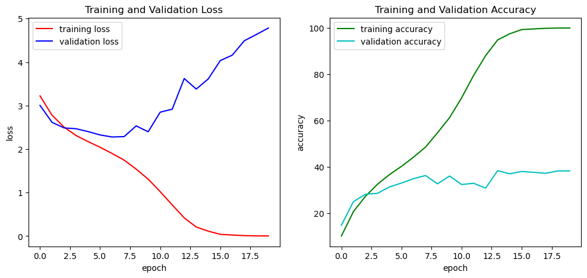

```python
plotGraphs(cnn_train_loss,cnn_val_loss,cnn_train_acc,cnn_val_acc)
```

```python
# Define top-*k* accuracy
def topk_accuracy(output, target, topk=(1,)):
    """Computes the precision@k for the specified values of k"""
    maxk = max(topk)
    batch_size = target.size(0)
    _, pred = output.topk(maxk, 1, True, True)
    pred = pred.t()
    correct = pred.eq(target.view(1, -1).expand_as(pred))

    res = []
    for k in topk:
        correct_k = correct[:k].view(-1).float().sum(0)
        res.append(correct_k.mul_(100.0 / batch_size))
    return res
```

> Comment on your model and results that should include number of parameters in each model and why CNN over MLP for image classification task?

### 2.2 Generating confusion matrix and ROC curves [4 marks]

- Use your CNN architecture with best accuracy to generate two confusion matrices, one for the training set and another for the validation set. Remember to use the whole validation and training sets, and to include all your relevant code. Display the confusion matrices in a meaningful way that clearly indicates what percentage of the data is represented in each position.
- Display ROC curve for 5 top classes with area under the curve

```
Training Confusion Matrix:
[[3.24074074 0.         0.00925926 0.         0.01851852 0.00925926
  0.         0.00925926 0.         0.         0.00925926 0.
  0.00925926 0.         0.         0.         0.00925926 0.00925926
  0.         0.         0.         0.         0.01851852 0.00925926
  0.         0.         0.         0.         0.         0.        ]
 [0.22222222 3.14814815 0.         0.         0.         0.
  0.         0.         0.         0.         0.         0.
  0.         0.         0.         0.         0.         0.
  0.         0.         0.         0.         0.         0.
  0.         0.         0.         0.         0.         0.        ]
 [0.31481481 0.         3.11111111 0.         0.00925926 0.
  0.         0.         0.         0.         0.         0.
  0.         0.         0.         0.         0.         0.
  0.         0.         0.         0.         0.         0.
  0.         0.         0.         0.         0.         0.00925926]
 [3.26851852 0.         0.         0.         0.         0.
  0.00925926 0.         0.         0.         0.         0.
  0.00925926 0.         0.00925926 0.         0.         0.
  0.         0.         0.         0.         0.00925926 0.
  0.         0.         0.00925926 0.01851852 0.00925926 0.00925926]
 [0.22222222 0.         0.01851852 0.         3.08333333 0.
  0.         0.         0.         0.         0.00925926 0.
  0.         0.         0.         0.         0.         0.
  0.         0.         0.         0.         0.         0.
  0.         0.         0.         0.         0.         0.        ]
 [0.31481481 0.         0.         0.         0.         3.06481481
  0.         0.         0.         0.01851852 0.00925926 0.
  0.         0.         0.         0.         0.         0.00925926
  0.         0.         0.         0.         0.         0.
  0.00925926 0.         0.         0.         0.         0.        ]
 [0.33333333 0.         0.         0.         0.         0.
  2.93518519 0.         0.         0.         0.         0.
  0.00925926 0.         0.         0.         0.         0.
  0.         0.         0.         0.         0.         0.
  0.         0.         0.         0.00925926 0.         0.        ]
 [0.49074074 0.         0.         0.         0.         0.00925926
  0.         3.05555556 0.         0.         0.         0.
  0.         0.         0.         0.         0.         0.
  0.         0.         0.         0.         0.         0.
```

[output cut: 248 more lines]

```
 [0.96296296 0.03703704 0.03703704 0.         0.         0.07407407
  0.22222222 0.03703704 0.         0.07407407 0.         0.
  0.07407407 0.         0.14814815 0.         0.62962963 0.07407407
  0.         0.         0.         0.         0.         0.03703704
  0.03703704 0.         0.         0.77777778 0.11111111 0.14814815]
 [2.03703704 0.07407407 0.07407407 0.         0.         0.14814815
  0.11111111 0.11111111 0.         0.03703704 0.         0.
  0.11111111 0.         0.07407407 0.         0.03703704 0.03703704
  0.         0.         0.         0.         0.03703704 0.03703704
  0.03703704 0.         0.07407407 0.03703704 0.55555556 0.11111111]
 [1.18518519 0.07407407 0.14814815 0.         0.         0.
  0.18518519 0.03703704 0.         0.         0.         0.
  0.22222222 0.         0.14814815 0.         0.07407407 0.11111111
  0.         0.         0.         0.         0.03703704 0.03703704
  0.03703704 0.         0.03703704 0.07407407 0.18518519 0.18518519]]
```

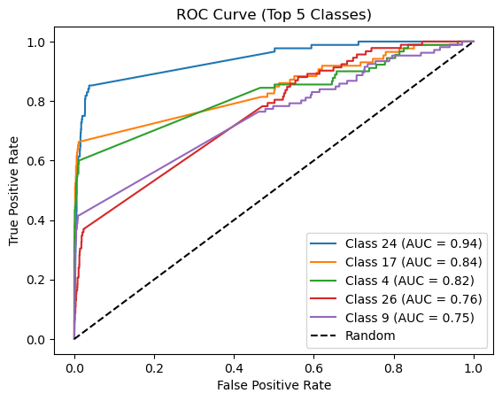

```python
# Your code here!
from sklearn.metrics import confusion_matrix, roc_curve, auc

fpr = dict()
tpr = dict()
roc_auc = dict()

train_cm = confusion_matrix(train_labels, train_preds)
val_cm = confusion_matrix(val_labels, val_preds)
# Print confusion matrices
print(f"Training Confusion Matrix: \n{train_cm/np.sum(train_cm)*100}\n")
print(f"Validation Confusion Matrix: \n{val_cm/np.sum(val_cm)*100}\n")
num_classes=30
# Calculate ROC curve and AUC for each class
for i in range(num_classes):
    fpr[i], tpr[i], _ = roc_curve(val_labels == i, val_probs[:, i])
    roc_auc[i] = auc(fpr[i], tpr[i])

# Sort ROC AUC values and select top 5 classes
sorted_auc = sorted(roc_auc.items(), key=lambda x: x[1], reverse=True)[:5]
top_classes = [x[0] for x in sorted_auc]

# Plot ROC curve for top 5 classes
plt.figure()
for i in top_classes:
    plt.plot(fpr[i], tpr[i], label=f"Class {i} (AUC = {roc_auc[i]:.2f})")
plt.plot([0, 1], [0, 1], 'k--', label='Random')
plt.xlabel('False Positive Rate')
plt.ylabel('True Positive Rate')
plt.title('ROC Curve (Top 5 Classes)')
plt.legend()
plt.show()
```

**Note: All parts below here relate to the CNN model only and not the MLP! You are advised to use your final CNN model only for each of the following parts.**

### 2.3 Strategies for tackling overfitting (9 marks)

Using your (final) CNN model, use the strategies below to avoid overfitting. You can reuse the network weights from previous training, often referred to as `fine tuning`.

- **2.3.1** Data augmentation
- **2.3.2** Dropout
- **2.3.3** Hyperparameter tuning (e.g. changing learning rate)

Plot loss and accuracy graphs per epoch side by side for each implemented strategy.

#### 2.3.1 Data augmentation

> Implement at least five different data augmentation techniques that should include both photometric and geometric augmentations.

> Provide graph and comment on what you observe

```python
# Your code here!
train_transforms = transforms.Compose([
        transforms.Resize((64,64)),
        transforms.RandomRotation(degrees=15),
        transforms.RandomHorizontalFlip(),
        transforms.RandomCrop(size=64, padding=4),
        transforms.ColorJitter(brightness=0.4, contrast=0.4, saturation=0.4, hue=0.1),
        transforms.GaussianBlur(kernel_size=3, sigma=(0.1, 5)),
        transforms.ToTensor(),
        transforms.Normalize((0.485, 0.456, 0.406), (0.229, 0.224, 0.225))
])

train_set1 = ImageFolder(root=DataPath, transform=train_transforms)
train_div1, val_div1 = train_test_split(range(len(train_set)), test_size=0.2, random_state=0)
train_data1 = torch.utils.data.Subset(train_set1, train_div1)
val_data1 = torch.utils.data.Subset(train_set1, val_div1)

train_loader1 = DataLoader(train_data1,batch_size=32,shuffle=True)
val_dataloader1 = DataLoader(val_data1, batch_size =32, shuffle=True)

def new_CNN1(epochs=20, learning_rate=0.01):
    nepochs = epochs
    cnn = CNN(l_rate=learning_rate)
    train_losses = []
    train_accs = []
    val_losses = []
    val_accs = []
    cnn.to('cuda:0')
    for epoch in range(nepochs):
        # Train the model for one epoch
        cnn.train()
        running_loss = 0.0
        correct = 0
        total = 0
        running_val_loss = 0.0
        num_val_samples = 0
        num_val_correct = 0
        train_preds = []
        train_labels = []
        val_preds = []
        val_labels = []
        val_probs = []
        for inputs, labels in train_loader:
            # Get the inputs and labels
            #inputs, labels = data
            inputs, labels = inputs.to('cuda:0'), labels.to('cuda:0')
            # Zero the parameter gradients
            cnn.optimizer.zero_grad()

            # Forward pass
            outputs = cnn(inputs)
            # Compute the loss
            loss = cnn.loss_fn(outputs, labels)
            # Backward pass and update weights
            loss.backward()
            cnn.optimizer.step()
            # Print statistics
            running_loss += loss.item() * inputs.size(0)
            _, predicted = torch.max(outputs.data, 1)
            total += inputs.size(0)
            correct += (predicted == labels).sum().item()
            train_preds.extend(predicted.cpu().numpy())
            train_labels.extend(labels.cpu().numpy())

        # Compute and record the average training loss and accuracy for this epoch
        train_loss = running_loss / len(train_loader.dataset)
        train_acc = 100 * correct / total
        train_losses.append(train_loss)
        train_accs.append(train_acc)

        with torch.no_grad():
            for images, labels in val_dataloader:
                images = images.to(device)
                labels = labels.to(device)
                output = cnn(images)
                loss = cnn.loss_fn(output, labels)
                running_val_loss += loss.item() * images.size(0)
                _, predicted = torch.max(output.data, 1)
                num_val_samples += images.size(0)
                num_val_correct += (predicted == labels).sum().item()
                val_preds.extend(predicted.cpu().numpy())
                val_labels.extend(labels.cpu().numpy())
                probs = torch.nn.functional.softmax(output, dim=1)
                val_probs.extend(probs.cpu().numpy())

        val_loss = running_val_loss / num_val_samples
        val_acc = (num_val_correct / num_val_samples) * 100
        val_losses.append(val_loss)
        val_accs.append(val_acc)
        val_probs = np.array(val_probs)
        val_labels = np.array(val_labels)

        # Print the training and validation losses and accuracies for the epoch
        print(f"Epoch {epoch+1} | Train Loss: {train_loss:.4f} | Train Acc: {train_acc:.4f} | Val Loss: {val_loss:.4f} | Val Acc: {val_acc:.4f}")
    return train_losses,train_accs,val_losses,val_accs, train_preds,train_labels,val_preds,val_labels,val_probs
```

```python
cnn_train_loss,cnn_train_acc,cnn_val_loss,cnn_val_acc, cnn_train_preds,cnn_train_labels,cnn_val_preds,cnn_val_labels,cnn_val_probs=new_CNN1()
```

```
Epoch 1 | Train Loss: 3.2067 | Train Acc: 10.4815 | Val Loss: 2.9502 | Val Acc: 16.1852
Epoch 2 | Train Loss: 2.7272 | Train Acc: 21.8611 | Val Loss: 2.7159 | Val Acc: 21.2593
Epoch 3 | Train Loss: 2.4513 | Train Acc: 28.9444 | Val Loss: 2.5031 | Val Acc: 27.9259
Epoch 4 | Train Loss: 2.2682 | Train Acc: 34.1574 | Val Loss: 2.4492 | Val Acc: 30.7037
Epoch 5 | Train Loss: 2.1223 | Train Acc: 38.0926 | Val Loss: 2.3141 | Val Acc: 33.8519
Epoch 6 | Train Loss: 1.9810 | Train Acc: 42.2685 | Val Loss: 2.5199 | Val Acc: 29.8519
Epoch 7 | Train Loss: 1.8223 | Train Acc: 46.2685 | Val Loss: 2.3528 | Val Acc: 34.8519
Epoch 8 | Train Loss: 1.6228 | Train Acc: 52.0556 | Val Loss: 2.4333 | Val Acc: 35.1481
Epoch 9 | Train Loss: 1.3909 | Train Acc: 58.8796 | Val Loss: 2.4032 | Val Acc: 34.7778
Epoch 10 | Train Loss: 1.1324 | Train Acc: 66.3981 | Val Loss: 2.5609 | Val Acc: 33.9259
Epoch 11 | Train Loss: 0.8170 | Train Acc: 76.2037 | Val Loss: 2.6327 | Val Acc: 36.1852
Epoch 12 | Train Loss: 0.4960 | Train Acc: 85.5556 | Val Loss: 3.0726 | Val Acc: 34.5185
Epoch 13 | Train Loss: 0.2606 | Train Acc: 92.9444 | Val Loss: 3.4898 | Val Acc: 34.0741
Epoch 14 | Train Loss: 0.1253 | Train Acc: 97.1759 | Val Loss: 3.7235 | Val Acc: 35.2222
Epoch 15 | Train Loss: 0.0516 | Train Acc: 99.0278 | Val Loss: 4.2113 | Val Acc: 35.6296
Epoch 16 | Train Loss: 0.0264 | Train Acc: 99.5648 | Val Loss: 4.3159 | Val Acc: 36.6667
Epoch 17 | Train Loss: 0.0149 | Train Acc: 99.7963 | Val Loss: 4.6244 | Val Acc: 35.4815
Epoch 18 | Train Loss: 0.0053 | Train Acc: 99.9630 | Val Loss: 4.8260 | Val Acc: 36.2963
Epoch 19 | Train Loss: 0.0024 | Train Acc: 100.0000 | Val Loss: 4.9899 | Val Acc: 36.6296
Epoch 20 | Train Loss: 0.0018 | Train Acc: 100.0000 | Val Loss: 5.1117 | Val Acc: 36.5556
```

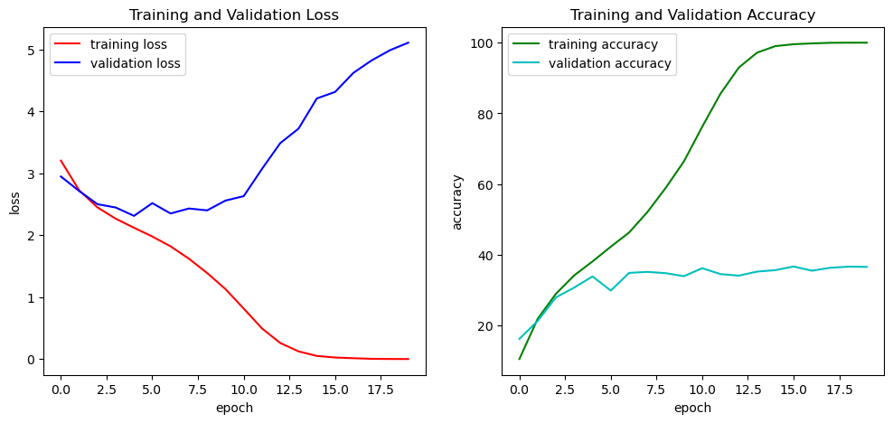

```python
plotGraphs(cnn_train_loss,cnn_val_loss,cnn_train_acc,cnn_val_acc)
```

#### 2.3.2 Dropout

> Implement dropout in your model

> Provide graph and comment on your choice of proportion used

```python
# Your code here!
import torch.nn as nn
import torch.optim as optim

class CNN1(nn.Module):
    def __init__(self, l_rate, dropout_prob):
        super(CNN1, self).__init__()

        self.flat= nn.Flatten()
        # Define convolutional layers
        self.conv1 = nn.Conv2d(3, 32, kernel_size=3)
        self.conv2 = nn.Conv2d(32, 64, kernel_size=3)
        self.conv3 = nn.Conv2d(64, 128, kernel_size=3)

        # Define fully-connected layers
        self.fc1 = nn.Linear(128 * 28 * 28, 128)
        self.fc2 = nn.Linear(128, 30)

        self.pool = nn.MaxPool2d(kernel_size=2)
        self.dropout = nn.Dropout(p=dropout_prob)

        # Define activation functions
        self.relu = nn.ReLU()
        #self.log_softmax = nn.LogSoftmax(dim=1)

        # Define loss function and optimizer
        self.loss_fn = nn.CrossEntropyLoss()
        self.optimizer = optim.SGD(self.parameters(), lr=l_rate)


    def forward(self, x):

        # Perform convolutional operations and activation functions
        x = self.relu(self.conv1(x))
        x = self.relu(self.conv2(x))
        x = self.pool(x)
        x = self.relu(self.conv3(x))

        # Flatten the output
        x = x.view(x.size(0),-1)
        x = self.dropout(x)

        # Perform fully-connected operations and activation functions
        x = self.relu(self.fc1(x))
        x = self.fc2(x)
        #x = self.log_softmax(x)

        return x


def new_CNN2(epochs=20, l_rate=0.01, dropout=0.3):
    nepochs = epochs
    cnn = CNN1(l_rate=l_rate,dropout_prob=dropout)
    train_losses = []
    train_accs = []
    val_losses = []
    val_accs = []
    cnn.to('cuda:0')
    #device = torch.device('cuda' if torch.cuda.is_available() else 'cpu')
    for epoch in range(nepochs):
        # Train the model for one epoch
        cnn.train()
        running_loss = 0.0
        correct = 0
        total = 0
        running_val_loss = 0.0
        num_val_samples = 0
        num_val_correct = 0
        train_preds = []
        train_labels = []
        val_preds = []
        val_labels = []
        val_probs = []
        for inputs, labels in train_loader:
            # Get the inputs and labels
            #inputs, labels = data
            inputs, labels = inputs.to('cuda:0'), labels.to('cuda:0')
            # Zero the parameter gradients
            cnn.optimizer.zero_grad()

            # Forward pass
            outputs = cnn(inputs)

            # Compute the loss
            loss = cnn.loss_fn(outputs, labels)

            # Backward pass and update weights
            loss.backward()
            cnn.optimizer.step()

            # Print statistics
            running_loss += loss.item()
            _, predicted = torch.max(outputs.data, 1)
            total += labels.size(0)
            correct += (predicted == labels).sum().item()
            train_preds.extend(predicted.cpu().numpy())
            train_labels.extend(labels.cpu().numpy())

        # Compute and record the average training loss and accuracy for this epoch
        train_loss = running_loss / len(train_loader.dataset)
        train_acc = 100 * correct / total
        train_losses.append(train_loss)
        train_accs.append(train_acc)

        with torch.no_grad():
            for batch_idx, (images, labels) in enumerate(val_dataloader):
                images = images.to(device)
                labels = labels.to(device)
                cnn1 = cnn.to(device)  # move model to device
                output = cnn1(images)
                loss = cnn1.loss_fn(output, labels)
                running_val_loss += loss.item() * images.size(0)
                num_val_samples += images.size(0)
                _, predicted = torch.max(output.data, 1)
                num_val_correct += (predicted == labels).sum().item()
                val_preds.extend(predicted.cpu().numpy())
                val_labels.extend(labels.cpu().numpy())
                probs = torch.nn.functional.softmax(output, dim=1)
                val_probs.extend(probs.cpu().numpy())

        # Compute the validation loss and accuracy for the epoch
        val_loss = running_val_loss / num_val_samples
        val_acc = (num_val_correct / num_val_samples) * 100
        val_losses.append(val_loss)
        val_accs.append(val_acc)
        val_probs = np.array(val_probs)
        val_labels = np.array(val_labels)

        # Print the training and validation losses and accuracies for the epoch
        print(f"Epoch {epoch+1} | Train Loss: {train_loss:.4f} | Train Acc: {train_acc:.4f} | Val Loss: {val_loss:.4f} | Val Acc: {val_acc:.4f}")
    return train_losses,train_accs,val_losses,val_accs, train_preds,train_labels,val_preds,val_labels,val_probs
```

```python
cnn_train_loss,cnn_train_acc,cnn_val_loss,cnn_val_acc, cnn_train_preds,cnn_train_labels,cnn_val_preds,cnn_val_labels,cnn_val_probs=new_CNN2()
```

```
Epoch 1 | Train Loss: 0.0997 | Train Acc: 10.6759 | Val Loss: 2.9277 | Val Acc: 15.7778
Epoch 2 | Train Loss: 0.0859 | Train Acc: 20.9167 | Val Loss: 2.6262 | Val Acc: 23.2963
Epoch 3 | Train Loss: 0.0773 | Train Acc: 28.5000 | Val Loss: 2.5229 | Val Acc: 28.2963
Epoch 4 | Train Loss: 0.0716 | Train Acc: 33.4444 | Val Loss: 2.5694 | Val Acc: 27.4444
Epoch 5 | Train Loss: 0.0668 | Train Acc: 37.7407 | Val Loss: 2.3748 | Val Acc: 31.8889
Epoch 6 | Train Loss: 0.0620 | Train Acc: 42.0833 | Val Loss: 2.3970 | Val Acc: 30.9259
Epoch 7 | Train Loss: 0.0575 | Train Acc: 45.4630 | Val Loss: 2.3559 | Val Acc: 34.3704
Epoch 8 | Train Loss: 0.0518 | Train Acc: 51.1111 | Val Loss: 2.4895 | Val Acc: 32.9259
Epoch 9 | Train Loss: 0.0448 | Train Acc: 57.8981 | Val Loss: 2.4464 | Val Acc: 34.5556
Epoch 10 | Train Loss: 0.0368 | Train Acc: 65.1019 | Val Loss: 2.6281 | Val Acc: 33.4444
Epoch 11 | Train Loss: 0.0274 | Train Acc: 73.7778 | Val Loss: 2.7792 | Val Acc: 34.4444
Epoch 12 | Train Loss: 0.0180 | Train Acc: 83.2407 | Val Loss: 3.3993 | Val Acc: 32.1481
Epoch 13 | Train Loss: 0.0101 | Train Acc: 91.2037 | Val Loss: 3.9725 | Val Acc: 29.0000
Epoch 14 | Train Loss: 0.0057 | Train Acc: 95.2130 | Val Loss: 3.6826 | Val Acc: 33.7037
Epoch 15 | Train Loss: 0.0028 | Train Acc: 97.9815 | Val Loss: 4.0291 | Val Acc: 34.8519
Epoch 16 | Train Loss: 0.0015 | Train Acc: 98.9815 | Val Loss: 4.3692 | Val Acc: 34.8889
Epoch 17 | Train Loss: 0.0014 | Train Acc: 99.1389 | Val Loss: 4.3408 | Val Acc: 36.2222
Epoch 18 | Train Loss: 0.0006 | Train Acc: 99.6759 | Val Loss: 4.6597 | Val Acc: 35.7037
Epoch 19 | Train Loss: 0.0005 | Train Acc: 99.7963 | Val Loss: 4.6691 | Val Acc: 36.0741
Epoch 20 | Train Loss: 0.0003 | Train Acc: 99.9352 | Val Loss: 4.8236 | Val Acc: 37.2222
```

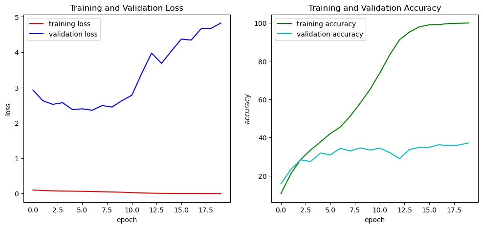

```python
plotGraphs(cnn_train_loss,cnn_val_loss,cnn_train_acc,cnn_val_acc)
```

#### 2.3.3 Hyperparameter tuning

> Use learning rates [0.1, 0.001, 0.0001]

> Provide separate graphs for loss and accuracy, each showing performance at three different learning rates

```python
# Your code here!
print("Learning rate=0.001")
cnn_train_loss1,cnn_train_acc1,cnn_val_loss1,cnn_val_acc1, cnn_train_preds1,cnn_train_labels1,cnn_val_preds1,cnn_val_labels1,cnn_val_probs1=new_CNN(learning_rate=0.001)
print("Learning rate=0.01")
# Your code here!
cnn_train_loss2,cnn_train_acc2,cnn_val_loss2,cnn_val_acc2, cnn_train_preds2,cnn_train_labels2,cnn_val_preds2,cnn_val_labels2,cnn_val_probs2=new_CNN(learning_rate=0.01)
# Your code here!
print("Learning rate=0.1")
cnn_train_loss3,cnn_train_acc3,cnn_val_loss3,cnn_val_acc3, cnn_train_preds3,cnn_train_labels3,cnn_val_preds3,cnn_val_labels3,cnn_val_probs3=new_CNN(learning_rate=0.1)
```

```
Learning rate=0.001
Epoch 1 | Train Loss: 3.3877 | Train Acc: 7.2500 | Val Loss: 3.3707 | Val Acc: 9.7037
Epoch 2 | Train Loss: 3.3441 | Train Acc: 11.0648 | Val Loss: 3.3156 | Val Acc: 11.8519
Epoch 3 | Train Loss: 3.2665 | Train Acc: 12.6111 | Val Loss: 3.2185 | Val Acc: 13.9259
Epoch 4 | Train Loss: 3.1486 | Train Acc: 14.8426 | Val Loss: 3.0774 | Val Acc: 17.0370
Epoch 5 | Train Loss: 3.0077 | Train Acc: 17.6111 | Val Loss: 2.9434 | Val Acc: 18.0000
Epoch 6 | Train Loss: 2.8852 | Train Acc: 19.2222 | Val Loss: 2.8679 | Val Acc: 19.5926
Epoch 7 | Train Loss: 2.7901 | Train Acc: 21.9259 | Val Loss: 2.7942 | Val Acc: 20.3333
Epoch 8 | Train Loss: 2.7138 | Train Acc: 23.8426 | Val Loss: 2.7205 | Val Acc: 23.4074
Epoch 9 | Train Loss: 2.6469 | Train Acc: 25.3056 | Val Loss: 2.6818 | Val Acc: 23.2222
Epoch 10 | Train Loss: 2.5808 | Train Acc: 27.0926 | Val Loss: 2.6568 | Val Acc: 24.0741
Epoch 11 | Train Loss: 2.5170 | Train Acc: 29.6019 | Val Loss: 2.6331 | Val Acc: 25.0370
Epoch 12 | Train Loss: 2.4559 | Train Acc: 31.0648 | Val Loss: 2.5773 | Val Acc: 27.4815
Epoch 13 | Train Loss: 2.3966 | Train Acc: 32.2315 | Val Loss: 2.5159 | Val Acc: 29.1111
Epoch 14 | Train Loss: 2.3351 | Train Acc: 33.5833 | Val Loss: 2.4717 | Val Acc: 30.0000
Epoch 15 | Train Loss: 2.2867 | Train Acc: 34.7222 | Val Loss: 2.4637 | Val Acc: 29.7778
Epoch 16 | Train Loss: 2.2346 | Train Acc: 36.1296 | Val Loss: 2.4427 | Val Acc: 30.3333
Epoch 17 | Train Loss: 2.1902 | Train Acc: 37.2222 | Val Loss: 2.4247 | Val Acc: 31.1852
Epoch 18 | Train Loss: 2.1479 | Train Acc: 38.5556 | Val Loss: 2.4387 | Val Acc: 31.1852
Epoch 19 | Train Loss: 2.1062 | Train Acc: 39.7593 | Val Loss: 2.4127 | Val Acc: 31.5926
Epoch 20 | Train Loss: 2.0645 | Train Acc: 41.3333 | Val Loss: 2.3915 | Val Acc: 32.8148
Learning rate=0.01
Epoch 1 | Train Loss: 3.2228 | Train Acc: 9.7593 | Val Loss: 3.0389 | Val Acc: 13.3704
Epoch 2 | Train Loss: 2.7670 | Train Acc: 20.7500 | Val Loss: 2.6631 | Val Acc: 24.2222
Epoch 3 | Train Loss: 2.4885 | Train Acc: 27.8981 | Val Loss: 2.6349 | Val Acc: 24.5926
Epoch 4 | Train Loss: 2.3035 | Train Acc: 33.2222 | Val Loss: 2.4559 | Val Acc: 27.8148
Epoch 5 | Train Loss: 2.1551 | Train Acc: 37.0926 | Val Loss: 2.4680 | Val Acc: 31.1852
Epoch 6 | Train Loss: 2.0107 | Train Acc: 41.3056 | Val Loss: 2.2664 | Val Acc: 35.9259
Epoch 7 | Train Loss: 1.8565 | Train Acc: 45.4537 | Val Loss: 2.3199 | Val Acc: 34.8148
Epoch 8 | Train Loss: 1.6787 | Train Acc: 50.6019 | Val Loss: 2.3491 | Val Acc: 36.0370
Epoch 9 | Train Loss: 1.4609 | Train Acc: 56.7130 | Val Loss: 2.4144 | Val Acc: 35.1481
Epoch 10 | Train Loss: 1.1971 | Train Acc: 64.0093 | Val Loss: 2.4428 | Val Acc: 36.1111
Epoch 11 | Train Loss: 0.8834 | Train Acc: 73.5370 | Val Loss: 2.7339 | Val Acc: 35.1852
Epoch 12 | Train Loss: 0.5768 | Train Acc: 83.1204 | Val Loss: 2.8661 | Val Acc: 35.7778
Epoch 13 | Train Loss: 0.2922 | Train Acc: 91.9630 | Val Loss: 3.4796 | Val Acc: 33.5185
Epoch 14 | Train Loss: 0.1476 | Train Acc: 96.6019 | Val Loss: 3.7561 | Val Acc: 33.0741
Epoch 15 | Train Loss: 0.0724 | Train Acc: 98.5278 | Val Loss: 4.1560 | Val Acc: 34.3704
Epoch 16 | Train Loss: 0.0203 | Train Acc: 99.7870 | Val Loss: 4.3416 | Val Acc: 35.5185
Epoch 17 | Train Loss: 0.1027 | Train Acc: 98.5000 | Val Loss: 3.3454 | Val Acc: 32.8519
Epoch 18 | Train Loss: 0.0569 | Train Acc: 99.0833 | Val Loss: 3.6827 | Val Acc: 36.0370
```

[output cut: 8 more lines]

```
Epoch 6 | Train Loss: 0.9618 | Train Acc: 71.3241 | Val Loss: 3.0270 | Val Acc: 28.8889
Epoch 7 | Train Loss: 0.3711 | Train Acc: 88.7870 | Val Loss: 5.3271 | Val Acc: 23.1852
Epoch 8 | Train Loss: 0.1613 | Train Acc: 95.0926 | Val Loss: 4.8252 | Val Acc: 29.5185
Epoch 9 | Train Loss: 0.1026 | Train Acc: 97.0185 | Val Loss: 6.1350 | Val Acc: 25.3333
Epoch 10 | Train Loss: 0.1871 | Train Acc: 94.7963 | Val Loss: 7.1277 | Val Acc: 24.5185
Epoch 11 | Train Loss: 0.1047 | Train Acc: 96.9352 | Val Loss: 5.4080 | Val Acc: 28.2222
Epoch 12 | Train Loss: 0.0513 | Train Acc: 98.4444 | Val Loss: 6.0334 | Val Acc: 28.2222
Epoch 13 | Train Loss: 0.1015 | Train Acc: 97.1111 | Val Loss: 5.9127 | Val Acc: 29.3333
Epoch 14 | Train Loss: 0.0851 | Train Acc: 97.8333 | Val Loss: 6.8333 | Val Acc: 25.3333
Epoch 15 | Train Loss: 0.0879 | Train Acc: 97.4907 | Val Loss: 6.2778 | Val Acc: 25.8889
Epoch 16 | Train Loss: 0.0436 | Train Acc: 98.7130 | Val Loss: 6.9269 | Val Acc: 29.1111
Epoch 17 | Train Loss: 0.0063 | Train Acc: 99.7963 | Val Loss: 8.4705 | Val Acc: 28.4444
Epoch 18 | Train Loss: 0.0035 | Train Acc: 99.8981 | Val Loss: 7.6401 | Val Acc: 29.7778
Epoch 19 | Train Loss: 0.0004 | Train Acc: 100.0000 | Val Loss: 7.7176 | Val Acc: 29.7778
Epoch 20 | Train Loss: 0.0001 | Train Acc: 100.0000 | Val Loss: 7.7997 | Val Acc: 29.8148
```

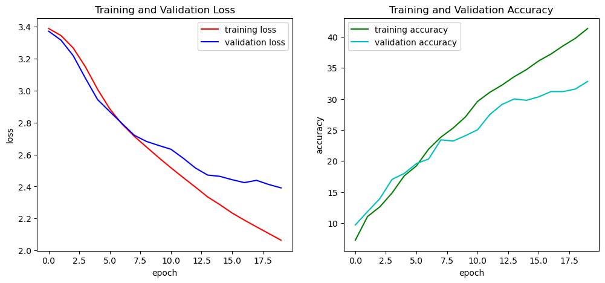

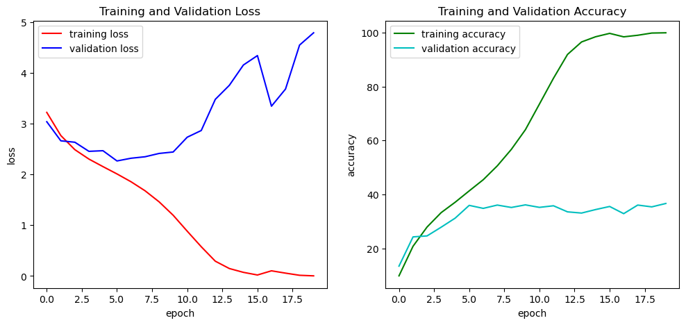

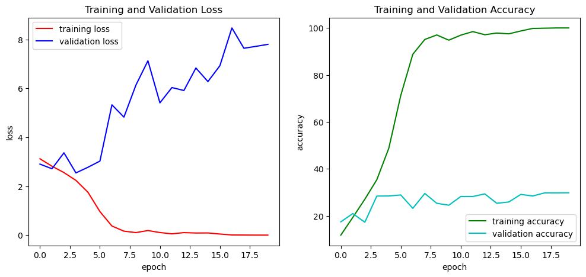

```python
# Your graph
plotGraphs(cnn_train_loss1,cnn_val_loss1,cnn_train_acc1,cnn_val_acc1)

plotGraphs(cnn_train_loss2,cnn_val_loss2,cnn_train_acc2,cnn_val_acc2)

plotGraphs(cnn_train_loss3,cnn_val_loss3,cnn_train_acc3,cnn_val_acc3)
```

### 3 Model testing [18 marks]

Online evaluation of your model performance on the test set.

> Prepare the dataloader for test set

> Write evaluation code for writing predictions

> Upload it to Kaggle submission page [link](https://www.kaggle.com/t/917fe52f6a3c4855880a24b34f26db07)

#### 3.1 Test class and predictions [10 marks]

> Build a test class, prepare a test dataloader and generate predictions

Create a PyTorch `Dataset` for the unlabeled test data in the test_set folder of the Kaggle competition and generate predictions using your final model. Test data can be downloaded [here](https://www.kaggle.com/competitions/comp5623m-artificial-intelligence/data?select=test_set)

```python
# Your code here!
test_set = LoadFromFolder(main_dir=ResultPath, transform=transforms.ToTensor())
test_loader = DataLoader(test_set,batch_size=32, shuffle=False)
testiter = iter(test_loader)
# images, labels = dataiter.next()
test_images = next(testiter)

print(next(iter(test_loader)).shape)
print(test_images.size())
```

```
torch.Size([32, 3, 64, 64])
torch.Size([32, 3, 64, 64])
```

```python
model = CNN(l_rate=0.01)

import pandas as pd
model=model.to(device)
def test(model, test_loader, device):
    model.eval()
    predictions = []
    with torch.no_grad():
        for batch_idx, images in enumerate(test_loader):
            images = images.to(device)
            output = model(images)
            _, predicted = torch.max(output.data, 1)
            predicted = predicted.cpu().numpy().tolist()
            #image_ids = image_ids.cpu().numpy().tolist()
            predictions.extend(list(zip(predicted)))
    df = pd.DataFrame(predictions, columns=['Category'])
    print(df)
    #df.to_csv('sc22angs.csv', index=False)
test(model,test_loader, device)
```

```
      Category
0           18
1           20
2           18
3           18
4           18
...        ...
1495        18
1496        18
1497        18
1498        18
1499        18

[1500 rows x 1 columns]
```

#### 3.2 Prepare your submission and upload to Kaggle [8 marks]

Save all test predictions to a CSV file and submit it to the private class Kaggle competition. **Please save your test CSV file submissions using your student username (the one with letters, ie., `sc15jb`, not the ID with only numbers)**, for example, `sc15jb.csv`. That will help us to identify your submissions.

The CSV file must contain only two columns: ‘Id’ and ‘Category’ (predicted class ID) as shown below:

```
txt
Id,Category
28d0f5e9_373c.JPEG,2
bbe4895f_40bf.JPEG,18
```

Please note you will get marks for higher performance.

The ‘Id’ column should include the name of the image. It is important to keep the same name as the one on the test set. Do not include any path, just the name of file (with extension). Your csv file must contain 1501 rows, one for each image in the test set and 1 row for the headers. [To submit please visit](https://www.kaggle.com/t/917fe52f6a3c4855880a24b34f26db07)

> You may submit multiple times. We will use your personal top entry for allocating marks for this [8 marks]. The class leaderboard will not affect marking (brownie points!).

```python
# Your code here!
```

### 4 Model Fine-tuning/transfer learning on CIFAR10 dataset [20 marks]

Fine-tuning is a way of applying or utilizing transfer learning. It is a process that takes a model that has already been trained for one task and then tunes or tweaks the model to make it perform a second similar task. You can perform finetuning in the following way:

- Train an entire model from scratch (large dataset, more computation)
- Freeze convolution base and train only last FC layers (small dataset and lower computation)

> **Configuring your dataset**
> - Download your dataset using `torchvision.datasets.CIFAR10`, [explained here](https://pytorch.org/vision/stable/generated/torchvision.datasets.CIFAR10.html)
> - Split training dataset into training and validation set similar to above. *Note that the number of categories here are only 10*

```python
# Your code here!
import torch
import torchvision
import torchvision.transforms as transforms
from sklearn.model_selection import train_test_split
import time
train_transform = transforms.Compose([
    transforms.Resize((224,224)),
    transforms.ToTensor(),
    transforms.Normalize((0.485, 0.456, 0.406), (0.229, 0.224, 0.225))
])

train_set = torchvision.datasets.CIFAR10(root='./data', train=True,
                                        download=True, transform=train_transform)
train_div, val_div = train_test_split(range(len(train_set)), test_size=0.2, random_state=0)
train_data = torch.utils.data.Subset(train_set, train_div)
val_data = torch.utils.data.Subset(train_set, val_div)

train_loader_new = DataLoader(train_data,batch_size=32,shuffle=True)
val_dataloader_new = DataLoader(val_data, batch_size =32, shuffle=True)
```

```
Files already downloaded and verified
```

> Load pretrained AlexNet from PyTorch - use model copies to apply transfer learning in different configurations

```python
# Your code here!
# Your code here!
import torchvision.models as models

# Load pre-trained AlexNet
alexnet = models.alexnet(pretrained=True)
```

#### 4.1 Apply transfer learning initialise with pretrained model weights

Use pretrained weights from AlexNet only (on the right of figure) to initialise your model.

[figure not shown]

Figure: Two models are given here: LeNet and AlexNet for image classification. However, you have to use **only AlexNet**.

> Configuration 1: No frozen layers

```python
# Your model changes here - also print trainable parameters
# Your model changes here - also print trainable parameters
import torchsummary
torch.manual_seed(40)
alexnet.classifier = nn.Sequential(nn.Linear(9216, 1024),
                                 nn.ReLU(),
                                 nn.Dropout(0.4),
                                 nn.Linear(1024, 10),
                                 nn.LogSoftmax(dim=1))
loss_fn = nn.CrossEntropyLoss()
optimizer = torch.optim.SGD(alexnet.classifier.parameters(),lr=0.001)


# TRAINABLE parameters:
alexnet.to(device)
torchsummary.summary(alexnet, input_size=(3, 224, 224), device='cuda')

# Unfreeze the convolutional base
for param in alexnet.features.parameters():
    param.requires_grad = True

nepochs = 10
train_losses = []
train_accs = []
val_losses = []
val_accs = []
exec_time_unfrozen=[]

for epoch in range(nepochs):
    # Train the model on the training set
    start_time=time.time()
    alexnet.train()
    running_loss = 0.0
    correct = 0
    total = 0
    running_val_loss = 0.0
    num_val_samples = 0
    num_val_correct = 0
    train_preds = []
    train_labels = []
    val_preds = []
    val_labels = []
    val_probs = []
    for inputs, labels in train_loader_new:
        inputs, labels = inputs.to('cuda:0'), labels.to('cuda:0')
        # Zero the parameter gradients
        optimizer.zero_grad()

        # Forward pass
        outputs = alexnet(inputs)

        # Compute the loss
        loss = loss_fn(outputs, labels)

        # Backward pass and update weights
        loss.backward()
        optimizer.step()

        # Print statistics
        running_loss += loss.item()
        _, predicted = torch.max(outputs.data, 1)
        total += labels.size(0)
        correct += (predicted == labels).sum().item()
        train_preds.extend(predicted.cpu().numpy())
        train_labels.extend(labels.cpu().numpy())

    # Compute and record the average training loss and accuracy for this epoch
    train_loss = running_loss / len(train_loader_new.dataset)
    train_acc = 100 * correct / total
    train_losses.append(train_loss)
    train_accs.append(train_acc)
    alexnet.eval()

    with torch.no_grad():
        for batch_idx, (images, labels) in enumerate(val_dataloader_new):
            images = images.to(device)
            labels = labels.to(device)
            output = alexnet(images)
            loss = loss_fn(output, labels)
            running_val_loss += loss.item() * images.size(0)
            num_val_samples += images.size(0)
            _, predicted = torch.max(output.data, 1)
            num_val_correct += (predicted == labels).sum().item()
            val_preds.extend(predicted.cpu().numpy())
            val_labels.extend(labels.cpu().numpy())
            probs = torch.nn.functional.softmax(output, dim=1)
            val_probs.extend(probs.cpu().numpy())

    # Compute the validation loss and accuracy for the epoch
    val_loss = running_val_loss / num_val_samples
    val_acc = (num_val_correct / num_val_samples) * 100
    val_losses.append(val_loss)
    val_accs.append(val_acc)
    val_probs = np.array(val_probs)
    val_labels = np.array(val_labels)
    end_time=time.time()-start_time
    exec_time_unfrozen.append(end_time)
    print(f"Epoch {epoch+1} | Train Loss: {train_loss:.4f} | Train Acc: {train_acc:.4f} | Val Loss: {val_loss:.4f} | Val Acc: {val_acc:.4f} | Exec time: {end_time:.4f}")
graphs_unfrozen=[]
graphs_unfrozen.append(train_losses)
graphs_unfrozen.append(val_losses)
graphs_unfrozen.append(train_accs)
graphs_unfrozen.append(val_accs)
```

```
=================================================================
Layer (type:depth-idx)                   Param #
=================================================================
├─Sequential: 1-1                        --
|    └─Conv2d: 2-1                       23,296
|    └─ReLU: 2-2                         --
|    └─MaxPool2d: 2-3                    --
|    └─Conv2d: 2-4                       307,392
|    └─ReLU: 2-5                         --
|    └─MaxPool2d: 2-6                    --
|    └─Conv2d: 2-7                       663,936
|    └─ReLU: 2-8                         --
|    └─Conv2d: 2-9                       884,992
|    └─ReLU: 2-10                        --
|    └─Conv2d: 2-11                      590,080
|    └─ReLU: 2-12                        --
|    └─MaxPool2d: 2-13                   --
├─AdaptiveAvgPool2d: 1-2                 --
├─Sequential: 1-3                        --
|    └─Linear: 2-14                      9,438,208
|    └─ReLU: 2-15                        --
|    └─Dropout: 2-16                     --
|    └─Linear: 2-17                      10,250
|    └─LogSoftmax: 2-18                  --
=================================================================
Total params: 11,918,154
Trainable params: 11,918,154
Non-trainable params: 0
=================================================================
Epoch 1 | Train Loss: 0.0381 | Train Acc: 62.7450 | Val Loss: 0.7925 | Val Acc: 75.3800 | Exec time: 151.9435
Epoch 2 | Train Loss: 0.0231 | Train Acc: 75.8125 | Val Loss: 0.6387 | Val Acc: 79.0300 | Exec time: 159.8723
Epoch 3 | Train Loss: 0.0196 | Train Acc: 78.9000 | Val Loss: 0.5762 | Val Acc: 81.0800 | Exec time: 157.2905
Epoch 4 | Train Loss: 0.0178 | Train Acc: 80.7125 | Val Loss: 0.5385 | Val Acc: 81.9200 | Exec time: 172.6514
Epoch 5 | Train Loss: 0.0165 | Train Acc: 82.1850 | Val Loss: 0.5126 | Val Acc: 82.7200 | Exec time: 174.6721
Epoch 6 | Train Loss: 0.0154 | Train Acc: 83.3050 | Val Loss: 0.4978 | Val Acc: 83.0600 | Exec time: 160.5696
Epoch 7 | Train Loss: 0.0146 | Train Acc: 84.2500 | Val Loss: 0.4846 | Val Acc: 83.3300 | Exec time: 164.2060
Epoch 8 | Train Loss: 0.0139 | Train Acc: 84.9275 | Val Loss: 0.4683 | Val Acc: 83.9800 | Exec time: 168.9930
Epoch 9 | Train Loss: 0.0134 | Train Acc: 85.5300 | Val Loss: 0.4604 | Val Acc: 84.2300 | Exec time: 165.7171
Epoch 10 | Train Loss: 0.0128 | Train Acc: 86.0950 | Val Loss: 0.4532 | Val Acc: 84.2600 | Exec time: 167.1786
```

#### 4.2 Fine-tuning model with frozen layers

> Configuration 2: Frozen base convolution blocks

```python
# Your changes here - also print trainable parameters
# Freeze the convolutional base
for param in alexnet.features.parameters():
    param.requires_grad = False

# Modify the classifier layers
alexnet.classifier = nn.Sequential(nn.Linear(9216, 1024),
                                    nn.ReLU(),
                                    nn.Dropout(0.4),
                                    nn.Linear(1024, 10),
                                    nn.LogSoftmax(dim=1))


# Move model to device
alexnet.to(device)

# Print model summary
torchsummary.summary(alexnet, input_size=(3, 224, 224), device='cuda')

# Set up loss function and optimizer
loss_fn = nn.CrossEntropyLoss()
optimizer = torch.optim.SGD(alexnet.classifier.parameters(), lr=0.001)

# Train the model
nepochs = 10
train_losses = []
train_accs = []
val_losses = []
val_accs = []
exec_time_frozen=[]

for epoch in range(nepochs):
    # Train the model on the training set
    start_time=time.time()
    alexnet.train()
    running_loss = 0.0
    correct = 0
    total = 0
    running_val_loss = 0.0
    num_val_samples = 0
    num_val_correct = 0
    train_preds = []
    train_labels = []
    val_preds = []
    val_labels = []
    val_probs = []

    for inputs, labels in train_loader_new:
        inputs, labels = inputs.to('cuda:0'), labels.to('cuda:0')
        # Zero the parameter gradients
        optimizer.zero_grad()

        # Forward pass
        outputs = alexnet(inputs)

        # Compute the loss
        loss = loss_fn(outputs, labels)

        # Backward pass and update weights
        loss.backward()
        optimizer.step()

        # Print statistics
        running_loss += loss.item()
        _, predicted = torch.max(outputs.data, 1)
        total += labels.size(0)
        correct += (predicted == labels).sum().item()
        train_preds.extend(predicted.cpu().numpy())
        train_labels.extend(labels.cpu().numpy())

    # Compute and record the average training loss and accuracy for this epoch
    train_loss = running_loss / len(train_loader_new.dataset)
    train_acc = 100 * correct / total
    train_losses.append(train_loss)
    train_accs.append(train_acc)
    alexnet.eval()

    with torch.no_grad():
        for batch_idx, (images, labels) in enumerate(val_dataloader_new):
            images = images.to(device)
            labels = labels.to(device)
            output = alexnet(images)
            loss = loss_fn(output, labels)
            running_val_loss += loss.item() * images.size(0)
            num_val_samples += images.size(0)
            _, predicted = torch.max(output.data, 1)
            num_val_correct += (predicted == labels).sum().item()
            val_preds.extend(predicted.cpu().numpy())
            val_labels.extend(labels.cpu().numpy())
            probs = torch.nn.functional.softmax(output, dim=1)
            val_probs.extend(probs.cpu().numpy())

    # Compute the validation loss and accuracy for the epoch
    val_loss = running_val_loss / num_val_samples
    val_acc = (num_val_correct / num_val_samples) * 100
    val_losses.append(val_loss)
    val_accs.append(val_acc)
    val_probs = np.array(val_probs)
    val_labels = np.array(val_labels)
    end_time=time.time()-start_time
    exec_time_frozen.append(end_time)
    print(f"Epoch {epoch+1} | Train Loss: {train_loss:.4f} | Train Acc: {train_acc:.4f} | Val Loss: {val_loss:.4f} | Val Acc: {val_acc:.4f} | Exec time: {end_time:.4f}")
```

[output not shown]

#### 4.3 Compare above configurations and comment on comparative performance

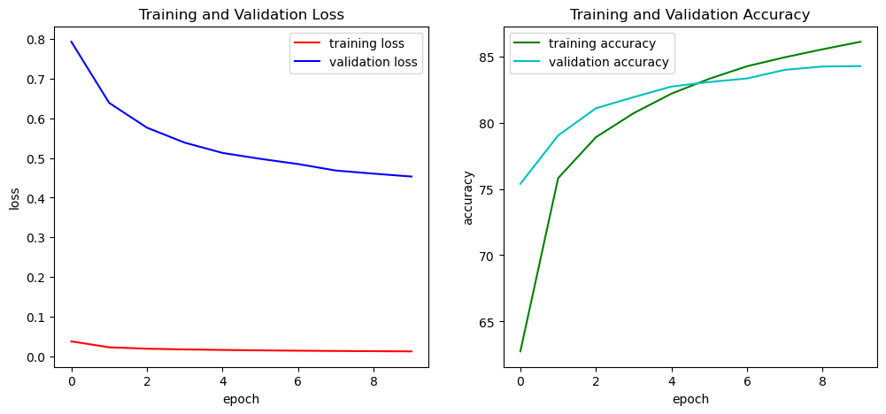

```python
# Your graphs here and please provide comment in markdown in another cell
plotGraphs(graphs_unfrozen[0],graphs_unfrozen[1],graphs_unfrozen[2],graphs_unfrozen[3])
```

[figure not shown]

```python
plotGraphs(train_losses,val_losses,train_accs,val_accs)
```

### 5 Model comparisons

We often need to compare our model with other state-of-the-art methods to understand how well it performs compared to existing architectures. Here you will thus compare your model design with AlexNet on the TinyImageNet30 dataset

#### 5.1 Finetune AlexNet on TinyImageNet30

> Load AlexNet as you did above

> Train AlexNet on TinyImageNet30 dataset until convergence. Make sure you use the same dataset

```python
# Your code here!

# Your model changes here - also print trainable parameters

alexnet = models.alexnet(pretrained=True)
alexnet.classifier = nn.Sequential(nn.Linear(9216, 1024),
                                    nn.ReLU(),
                                    nn.Dropout(0.4),
                                    nn.Linear(1024, 10),
                                    nn.LogSoftmax(dim=1))
nepochs = 10
train_losses = []
train_accs = []
val_losses = []
val_accs = []
exec_time_unfrozen=[]

for epoch in range(nepochs):
    # Train the model on the training set
    start_time=time.time()
    alexnet.train()
    running_loss = 0.0
    correct = 0
    total = 0
    running_val_loss = 0.0
    num_val_samples = 0
    num_val_correct = 0
    train_preds = []
    train_labels = []
    val_preds = []
    val_labels = []
    val_probs = []
    for inputs, labels in train_loader:
        #inputs, labels = inputs.to('cuda:0'), labels.to('cuda:0')
        # Zero the parameter gradients
        optimizer.zero_grad()

        # Forward pass
        outputs = alexnet(inputs)

        # Compute the loss
        loss = loss_fn(outputs, labels)

        # Backward pass and update weights
        loss.backward()

        optimizer.step()

        # Print statistics
        running_loss += loss.item()
        _, predicted = torch.max(outputs.data, 1)
        total += labels.size(0)
        correct += (predicted == labels).sum().item()
        train_preds.extend(predicted.cpu().numpy())
        train_labels.extend(labels.cpu().numpy())

    # Compute and record the average training loss and accuracy for this epoch
    train_loss = running_loss / len(train_loader.dataset)
    train_acc = 100 * correct / total
    train_losses.append(train_loss)
    train_accs.append(train_acc)
    alexnet.eval()

    with torch.no_grad():
        for batch_idx, (images, labels) in enumerate(val_dataloader):
            #images = images.to(device)
            #labels = labels.to(device)
            output = alexnet(images)
            loss = loss_fn(output, labels)
            running_val_loss += loss.item() * images.size(0)
            num_val_samples += images.size(0)
            _, predicted = torch.max(output.data, 1)
            num_val_correct += (predicted == labels).sum().item()
            val_preds.extend(predicted.cpu().numpy())
            val_labels.extend(labels.cpu().numpy())
            probs = torch.nn.functional.softmax(output, dim=1)
            val_probs.extend(probs.cpu().numpy())

    # Compute the validation loss and accuracy for the epoch
    val_loss = running_val_loss / num_val_samples
    val_acc = (num_val_correct / num_val_samples) * 100
    val_losses.append(val_loss)
    val_accs.append(val_acc)
    val_probs = np.array(val_probs)
    val_labels = np.array(val_labels)
    end_time=time.time()-start_time
    exec_time_unfrozen.append(end_time)
    print(f"Epoch {epoch+1} | Train Loss: {train_loss:.4f} | Train Acc: {train_acc:.4f} | Val Loss: {val_loss:.4f} | Val Acc: {val_acc:.4f} | Exec time: {end_time:.4f}")
graphs_unfrozen=[]
graphs_unfrozen.append(train_losses)
graphs_unfrozen.append(val_losses)
graphs_unfrozen.append(train_accs)
graphs_unfrozen.append(val_accs)
```

[output not shown]

#### 5.2 Compare results on validation set of TinyImageNet30

> Loss graph, top1 accuracy, confusion matrix and execution time for your model (say, mymodel and AlexNet)

```python
# Your code here!
```

```python
cnn_train_loss,cnn_train_acc,cnn_val_loss,cnn_val_acc, cnn_train_preds,cnn_train_labels,cnn_val_preds,cnn_val_labels,cnn_val_probs=new_CNN2()
```

```
Epoch 1 | Train Loss: 0.0997 | Train Acc: 10.6759 | Val Loss: 2.9277 | Val Acc: 15.7778
Epoch 2 | Train Loss: 0.0859 | Train Acc: 20.9167 | Val Loss: 2.6262 | Val Acc: 23.2963
Epoch 3 | Train Loss: 0.0773 | Train Acc: 28.5000 | Val Loss: 2.5229 | Val Acc: 28.2963
Epoch 4 | Train Loss: 0.0716 | Train Acc: 33.4444 | Val Loss: 2.5694 | Val Acc: 27.4444
Epoch 5 | Train Loss: 0.0668 | Train Acc: 37.7407 | Val Loss: 2.3748 | Val Acc: 31.8889
Epoch 6 | Train Loss: 0.0620 | Train Acc: 42.0833 | Val Loss: 2.3970 | Val Acc: 30.9259
Epoch 7 | Train Loss: 0.0575 | Train Acc: 45.4630 | Val Loss: 2.3559 | Val Acc: 34.3704
Epoch 8 | Train Loss: 0.0518 | Train Acc: 51.1111 | Val Loss: 2.4895 | Val Acc: 32.9259
Epoch 9 | Train Loss: 0.0448 | Train Acc: 57.8981 | Val Loss: 2.4464 | Val Acc: 34.5556
Epoch 10 | Train Loss: 0.0368 | Train Acc: 65.1019 | Val Loss: 2.6281 | Val Acc: 33.4444
Epoch 11 | Train Loss: 0.0274 | Train Acc: 73.7778 | Val Loss: 2.7792 | Val Acc: 34.4444
Epoch 12 | Train Loss: 0.0180 | Train Acc: 83.2407 | Val Loss: 3.3993 | Val Acc: 32.1481
Epoch 13 | Train Loss: 0.0101 | Train Acc: 91.2037 | Val Loss: 3.9725 | Val Acc: 29.0000
Epoch 14 | Train Loss: 0.0057 | Train Acc: 95.2130 | Val Loss: 3.6826 | Val Acc: 33.7037
Epoch 15 | Train Loss: 0.0028 | Train Acc: 97.9815 | Val Loss: 4.0291 | Val Acc: 34.8519
Epoch 16 | Train Loss: 0.0015 | Train Acc: 98.9815 | Val Loss: 4.3692 | Val Acc: 34.8889
Epoch 17 | Train Loss: 0.0014 | Train Acc: 99.1389 | Val Loss: 4.3408 | Val Acc: 36.2222
Epoch 18 | Train Loss: 0.0006 | Train Acc: 99.6759 | Val Loss: 4.6597 | Val Acc: 35.7037
Epoch 19 | Train Loss: 0.0005 | Train Acc: 99.7963 | Val Loss: 4.6691 | Val Acc: 36.0741
Epoch 20 | Train Loss: 0.0003 | Train Acc: 99.9352 | Val Loss: 4.8236 | Val Acc: 37.2222
```

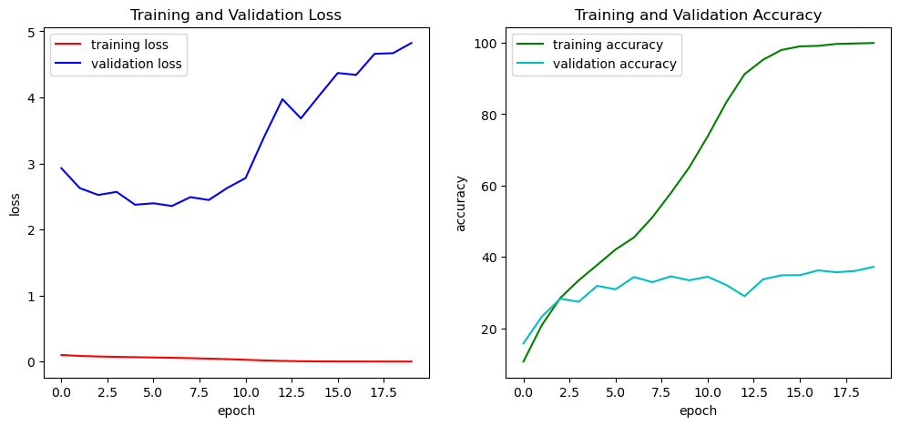

```python
plotGraphs(cnn_train_loss,cnn_val_loss,cnn_train_acc,cnn_val_acc)
```

### 6 Interpretation of results (16 marks)

> Please use TinyImageNet30 dataset for all results

#### 6.1-6.2 Implement grad-CAM and visualise results (10 marks)

- Use an existing library to initiate grad-CAM

  ```
    - To install: !pip install torchcam
    - Call SmoothGradCAMpp: from torchcam.methods import SmoothGradCAMpp
    - Apply to your model
  ```

You can see the details here: https://github.com/frgfm/torch-cam

- Apply grad-CAM to your model on at least four correctly classified images
- Apply grad-CAM on retrained AlexNet on at least four incorrectly classified images

> It is recommended to first read the relevant paper [Grad-CAM: Visual Explanations from Deep Networks via Gradient-based Localization](https://arxiv.org/abs/1610.02391), and refer to relevant course material.

**HINT for displaying images with grad-CAM:**

Display `heatmap` as a coloured heatmap superimposed onto the original image. We recommend the following steps to get a clear meaningful display.

From torchcam.utils import overlay_mask. But remember to resize your image, normalise it and put a 1 for the batch dimension (e.g, [1, 3, 224, 224])

```python
# Your code here!
```

```python
# Your code here!
```

```python
# Your code here!
```

#### 6.3 Your comments on (6 marks):

> a) Why model predictions were correct or incorrect? You can support your case from 6.2

> b) What can you do to improve your results further?

**Please refer to the submission section at the top of this notebook to prepare your submission. Use our teams channel to seek any help!**